# STA 108 Discussion 8: Multiple linear regression

# 5. Diagnosis

The residual plots and most diagnosis tests for multiple linear regression are similar to those for simple linear regression, we just add some special methods for multiple linear regression in this part. We continue to use "iris1" data.

## 5.1 Scatterplot matrix

Scatter plots of the response variable against each predictor variable can aid in determining the nature and strength of the bivariate relationships between each of the predictor variables and the response variable and in identifying gaps in the data points as well as outlying data points. Scatter plots of each predictor variable against each of the other predictor variables are helpful for studying the bivariate relationships among the predictor variables and for finding gaps and detecting outliers.

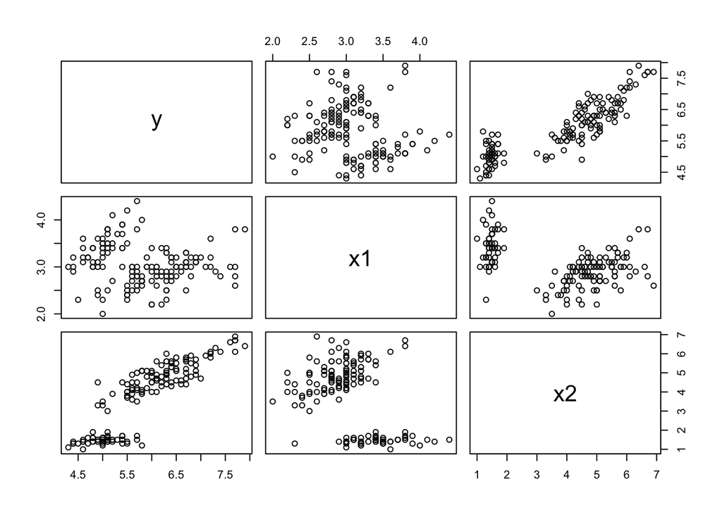

```r
pairs(iris1)
```

## 5.2 Correlation matrix

A complement to the scatter plot matrix that may be useful at times is the correlation matrix. This matrix contains the coefficients of simple correlation $r_{Y1}$, $r_{Y2}$, ... , $r_{Y,p-1}$ between Y and each of the predictor variables, as well as all of the coefficients of simple correlation among the predictor variables: $r_{12}$ between $X_1$ and $X_2$.

```r
cor(iris1)
```

```
##             y         x1         x2
## y   1.0000000 -0.1175698  0.8717538
## x1 -0.1175698  1.0000000 -0.4284401
## x2  0.8717538 -0.4284401  1.0000000
```

## 5.3 F-test for lack-of-fit

The lack of fit F test described in Chapter 3 for simple linear regression can be carried over to test whether the multiple regression response function is an appropriate response surface. Repeat observations in multiple regression are replicate observations on Y corresponding to levels of each of the X variables that are constant from trial to trial. Thus, with two predictor variables, repeat observations require that $X_1$ and $X_2$ each remain at given levels from trial to trial.
$$\begin{align*}
&H_0: E(Y)=\beta_0+\beta_1 X_1 +\cdots \beta_{p-1} X_{p-1}\\
&H_a: E(Y) \neq \beta_0+\beta_1 X +\cdots \beta_{p-1} X_{p-1}
\end{align*}$$

Under $H_0$, we get the reduced model with $df_R= n-p$. While under $H_a$, we get the full model $df_F=n-c$, where $c$ is the the number of groups with distinct sets of levels for the $X$ variables. The appropriate test statistic is:
$$F= \frac{(SSE_R-SSE_F)/(df_R-df_F)}{SSE_F/df_F}.$$
The p-value for this test is $P(F_{df_R-df_F, \ df_F}>F)$. The critical value for a given $\alpha$ is $F_{1-\alpha; \ df_R-df_F, \ df_F}$.

```r
reduce.model = lm(y~x1+x2, data=iris1)
full.model = lm(y~0+as.factor(x1):as.factor(x2), data=iris1)
kable(anova(reduce.model, full.model))
```

| Res.Df | RSS | Df | Sum of Sq | F | Pr(>F) |
| --- | --- | --- | --- | --- | --- |
| 147 | 16.328764 |  |  |  |  |
| 28 | 1.636667 | 119 | 14.6921 | 2.112198 | 0.0121407 |

Explanation for the dfs:

```r
Xs=cbind(iris1$x1, iris1$x2); Xlevels= unique(Xs)
c = nrow(Xlevels)
df_r= n-p;df_f= n-c
c(df_r,df_f)
```

```
## [1] 147  28
```